# Curso PostgreSQL

[figure not shown]

**Autor: Luis Fernando Apáez Álvarez**  
-Curso PyM-  
Clase 3: Llaves primarias y foráneas  
Fecha: Abril del 2023

## Llaves primarias

Desde las primeras clases hablamos sobre la importancia de tener un identificador en cada tabla de nuestra base de datos. Dijimos que la mayoría de las tablas deberían tener un `id` como identificador pues de esta forma optimizaríamos nuestra base de datos.

Ahora, veamos propiamente a lo que hace alusión ese identificador del que hablamos.

En cada tabla de nuestra base de datos debemos poder identificar de **manera única** cada fila dentro de ella, lo cual hace que la búsqueda de información sea mucho más precisa y rápida. Para ello nos basaremos en una columna (o conjunto de columnas) que logren realizar esta unicidad de la que hablamos. Así, a dicha columna (o conjunto de columnas) la denominaremos como **llave primaria** (o primary key), donde en la mayoría de los casos (no en todos) será el identificador `id` al que asignaremos como llave primaria.

Por ejemplo, considerando la siguiente tabla

| id_empleados | nombre | app | apm | puesto | salario | horario |
| --- | --- | --- | --- | --- | --- | --- |
| 50 | Pedro | López | López | Vigilante | 12500.5 | 00:00-12:00 |
| 100 | Lupe | López | Ocaña | Cajero | 9500.0 | 6:00-13:00 |
| 175 | Pedro | Álvarez | Cabello | Cajero | 9500.0 | 6:00-13:00 |

vemos que la columna `nombre` no puede ser llave primaria pues no identifica de manera única a cada fila de la tabla, pues vemos que hay dos entradas con el mismo valor `Pedro` dentro de esta columna. De la misma forma, las columnas `app, apm, puesto, salario` y `horario` no pueden ser llaves primarias. Vemos que claramente la columna `id_empleados` identifica de manera única cada fila de la tabla `empleados` por lo que definiremos a dicha columna como **llave primaria**. De hecho, si tuviéramos una columna que almace el CURP de cada persona, dicha columna podría ser también una llave primaria, de tal modo, podemos decir que dicha columna es una llave candidata. Del mismo modo, tendríamos que la columan `id_empleados` es también una llave candidata. En este ejemplo, cualquiera de ambas columnas es una buena opción para convertirse en llave primaria.

Cabe aclarar que considerando las columnas en conjunto `nombre, app` y `apm` podríamos tener también una llave primaria, pues es poco probable que dos personas tengan los mismos nombres y los mismo apellidos. No obstante, se elige como llave primaria a aquella que este conformada por el menor número de columnas.

Por otro lado, tenemos dos opciones para definir una **llave primaria**:

- Opción 1: definir la llave primaria cuando estamos creando la tabla en cuestión.

Por ejemplo, si apenas estamos creando la tabla empleados y escribimos

```
CREATE TABLE empleados(
    id_empleados INT,
    nombre VARCHAR,
    app VARCHAR,
    apm VARCHAR,
    puesto VARCHAR,
    salario real,
    horario VARCHAR
);
```

como deseamos que `id_empleados` sea la llave primaria entonces agregamos adicionalmente

```
CREATE TABLE empleados(
    id_empleados INT,
    nombre VARCHAR,
    app VARCHAR,
    apm VARCHAR,
    puesto VARCHAR,
    salario real,
    horario VARCHAR

    -- Agregamos la definicion de la llave primaria
    primary key(id_empleados)
);
```

Con lo anterior garantizamos que cada valor de la columna `id_empleados` sea único. Así, por ejemplo, si en algún momento queremos cambiar el valor del `id_empleados` de algún empleado y colocamos un número que ya está registrado, entonces *postgres* nos arrojará un error debido a la definición de llave primaria en esta columna. De igual forma al momento de ingresar un empleado nuevo, si le asignamos un `id_empleados` que ya existe previamente, de igual manera *postgres* nos arrojará un error. Además, al ser llave primaria esta columna no permite valores nulos.

- Opción 2 (recomendable)

Definiremos la llave primaria en una tabla que ya está almacenada en nuestra base de datos. Por ejemplo, dado que nosotros ya tenemos almacenada la tabla `empleados` en la base de datos, trabajaremos con esta opción para definir como llave primaria a la columna `id_empleados`. Para ello escribimos

```
ALTER TABLE empleados ADD CONSTRAINT pk_empleados_id_empleados
  PRIMARY KEY (id_empleados);
```

donde después de escribir `ADD CONSTRAINT` colocamos `pk_empleados_id_empleados` el cual es el nombre que le hemos asignado a dicha llave primaria. La convención es poner `pk_` (primary key) después el nombre de la tabla `pk_empleados` y finalmente el nombre de la columna que será la llave primaria `pk_empleados_id_empleados`. Finalmente, después de escribir `PRIMARY KEY` entre paréntesis indicamos la columna (o columnas) que serán la llave primaria de dicha tabla.

Una vez que ya hemos ejecutado el código veremos en la parte del menú de la izquierda que la llave primaria que hemos definido aparece en la parte de `constraints`

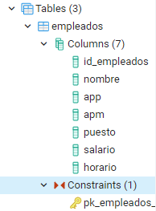

Si deseáramos eliminar una llave primaria utilizaríamos la siguiente sintaxis

```
ALTER TABLE <<nombre tabla>> DROP CONSTRAINT <<nombre llave primaria>>;
```

De tal manera, si quisiéramos eliminar la llave primaria que acabamos de definir escribiríamos algo como

```
ALTER TABLE empleados DROP CONSTRAINT pk_empleados_id_empleados;
```

Se recomienda entonces escribir primero el código para la creación de las tablas, posteriormente el código para la definición de las llaves primarias (y foráneas) y finalmente se procedería a la inserción de los datos. De nuevo, es preciso recordar que es imprescindible realizar primero un proceso de diseño antes de pasar a programar nuestras bases de datos, en dicho proceso de diseño definimos cuáles columnas serán las llaves primarias y foráneas, definimos el tipo de datos de las columnas, entre otros.

Antes de ver el tema de llave foránea es preciso realizar el siguiente ejercicio:

#### Ejercicio

- Definir una llave primaria en cada una de las tablas que tienes almacenadas en tu base de datos (referente al proyecto de la papelería).

## LLave foránea

En la Tarea 1 se dejo como ejercicio realizar al menos 3 inserciones en cada tabla presente en tu base de datos (referente al proyecto de la papelería). Tal vez notaste que existe una relación entre todas las tablas (de hecho es así, todas las tablas de nuestra base de datos deben relacionarse), puesto que estamos trabajando con bases de datos relacionales (aunque no lo hayamos dicho hasta ahora). Sin entrar en detalles, se denomina bases de datos relacionales a aquellas que cumplen con el modelo relacional y donde todas las relaciones (o también conocidas como tablas) están conectadas.

Considerando las tablas `empleados, ventas` y `productos` podemos notar que

- `empleados` está relacionada con `ventas` pues tenemos una columna denominada `empleado` en la tabla `ventas`.
- `ventas` está relacionada con `productos` pues tenemos una columna denominada `producto_vendido` en la tabla `ventas`.

Con base en lo anterior, las tres tablas mencionadas están relacionadas entre sí.

Luego, debe parecer lógico que un producto vendido este previamente declarado en la tabla productos, pues no podemos vender un producto del cual no tenemos registro. De tal manera, implícitamente tenemos una restricción sobre la columna `producto_vendido` de la tabla `ventas`, además, nos gustaría que en dicha columna no podamos ingresar valores que no estén previamente registrados en la columna `nombre_producto` de la tabla `productos`. Para ello haremos uso de las **llaves foráneas** (o Foreign key) la cual se define como una restricción referencial o de integridad, y justamente funciona para colocar una limitación a la hora de ingresar valores a una columna (o columnas).

Por ende, utilizaremos una **llave foránea** sobre la columna `producto_vendido` para imponer una restricción referencial a partir de la columna `nombre_producto` de la tabla `productos`. Es decir, estaremos imponiendo que todos los valores que sean ingresados en la columna `producto_vendido` de la tabla `ventas` estén previamente registrados en la columna `nombre_producto` de la tabla `productos`.

Por ejemplo, supongamos que ingresamos los siguientes datos

```
INSERT INTO productos(nombre_productos, cantidad_almacen, precio)
    VALUES('Pluma negra', 1000, 0.5);
INSERT INTO productos(nombre_productos, cantidad_almacen, precio)
    VALUES('Cuaderno blanco', 800, 20.9);

SELECT * FROM productos;
```

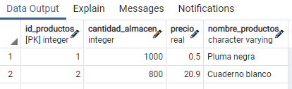

Recordemos de clases pasada que ya habíamos ingresado algunos empleados en la tabla `empleados`

```
SELECT * FROM empleados;
```

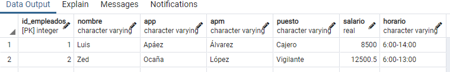

y después ingresamos los siguientes datos en la tabla `ventas`:

```
INSERT INTO ventas(producto_vendido, cantidad, total, empleado)
    VALUES('Pluma negra', 10, 5, 'Luis');
INSERT INTO ventas(producto_vendido, cantidad, total, empleado)
    VALUES('Engrapadora', 1, 55.5, 'Zed');

-- Consultamos
SELECT * FROM ventas;
```

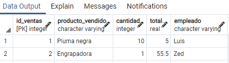

Sin problema alguno pudimos ingresar la información anterior, no obstante, hemos "vendido" un producto que no tenemos registrado en la tabla `productos`, lo cual representa un error grave para nuestro negocio pues no tenemos un correcto control sobre los productos que ofrecemos, lo cual puede representar pérdidas para el negocio. Por otro lado, vemos que en la columna `empleado` hemos colocado el nombre de un empleado, el cual está previamente registrado en la tabla `empleados`, así, en dicha columna estamos haciendo una correcta referencia.

Vemos que la referencia entre la tabla `empleados` y `ventas` es correcta, pero la referencia de la tabla `productos` y la tabla `ventas` no lo es. Lo anterior no podemos dejarlo "a la suerte" de quién ingresa la información, es decir, no podemos esperar que en algunas ocasiones la referencia con otras tablas sea correcta y en otros casos incorrecta. De tal manera, al definir la restricción de **llave foránea** en la columna `producto_vendido` de la tabla `ventas`con la columna `nombre_producto` de la tabla `productos` garantizamos que la referencia entre dichas columnas sea siempre correcta. Supongamos que ya definimos la llave foránea entre estas dos tablas, entonces, si ingresamos un producto vendido que no está previamente registrado en la tabla `productos`, entonces *postgres* nos arrojará un error referencial y no permitirá que se ingrese la información que pretendíamos ingresar. Así, también debemos definir una llave foránea entre las tablas `ventas` y `empleados` para que en la columna `empleado` de la tabla `ventas` tengamos sólo empleados previamente registrados en la tabla `empleados`.

De tal manera, la **llave foránea** se compone de dos tablas, una se conoce como tabla de referencia y la otra como tabla referenciada. En nuestro ejemplo tenemos que

| Tabla referenciada | Tabla de referencia |
| --- | --- |
| `empleados` | `ventas` |
| `productos` | `ventas` |

donde la **llave foránea** se define sobre la tabla de referencia. Entonces, para definir una **llave foránea** requerimos de una columna (o columnas) de la tabla de referencia y una columna (o columnas) de la tabla referenciada, donde la columna (o columnas) de la tabla referenciada debe tener la restricción de **llave primaria**.

Con base en lo anterior tendríamos un problema pues nosotros tenemos que

| Tabla referenciada | Tabla de referencia |
| --- | --- |
| `empleados`: columna `nombre` | `ventas`: columna `empleado` |
| `productos`: columna `nombre_productos` | `ventas`: columna `producto_vendido` |

las columnas de las tablas referenciadas no son llaves primarias en sus respectivas tablas, pues las llaves primarias las definimos sobre los id's. La solución del problemas sería considerar en la tabla `ventas` que las columnas `producto_vendido` y `empleado` reciban números enteros que hagan alusión a los id's del producto y de los empleados respectivamente.

Esto es, consideraremos algo como

| id_ventas | producto_vendido | cantidad | total | empleado |
| --- | --- | --- | --- | --- |
| 1 | 1 | 10 | 5 | 1 |
| 2 | 1 | 100 | 50 | 2 |

[figure not shown]

pero ahora tenemos todo lo necesario para definir las llaves foráneas que queremos.

Para conseguirlo, la manera más fácil (y la cual podemos hacer pues tenemos muy pocos datos) es eliminar y crear nuevamente la tabla `ventas` colocando el tipo de dato correcto en las columnas `producto_vendido` y `empleado`, pues recordemos que las habíamos definido con tipo de dato `VARCHAR` por lo que no se podrá ingresar números enteros, en cambio, al definir dichas columnas con el tipo de dato `int` tendremos el problema resuelto. Para ello escribimos

```
-- Eliminamos la tabla ventas
DROP TABLE ventas;

-- Creamos la tabla ventas
CREATE TABLE ventas(
    id_ventas SERIAL,
    id_producto_vendido INT,
    cantidad INT,
    total INT,
    id_empleado INT,
    PRIMARY KEY(id_ventas)
);
```

Ahora bien, antes de ingresar información a nuestra nueva tabla `ventas` definiremos las llaves foráneas de las que hemos estado hablando. Antes, veamos que

| Tabla referenciada | Tabla de referencia |
| --- | --- |
| `empleados`: columna `id_empleados` | `ventas`: columna `id_empleado` |
| `productos`: columna `id_productos` | `ventas`: columna `id_producto_vendido` |

de donde escribimos

```
-- FK (llave foránea) entre la tabla ventas y empleados
ALTER TABLE ventas ADD CONSTRAINT fk_ventas_id_empleado_id_empleados
    FOREIGN KEY (id_empleado) REFERENCES empleados(id_empleados);

-- FK entre la tabla ventas y productos
ALTER TABLE ventas ADD CONSTRAINT fk_ventas_id_producto_vendido_id_productos
    FOREIGN KEY (id_producto_vendido) REFERENCES productos(id_productos);
```

donde la sintaxis general es

```
ALTER TABLE <<tabla referencia>> ADD CONSTRAINT fk_<<columna referencia>>_<<columna referenciada>>
FOREING KEY (<<columna referencia>>) REFERENCES <<tabla referenciada>>(<<columna referenciada>>);
```

Vemos que las llaves foráneas aparecen en el menú de la izquierda en la parte de `constraints`

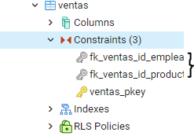

Ahora si, ingresamos información a nuestra tabla `ventas`

```
INSERT INTO ventas(id_producto_vendido, cantidad, total, id_empleado) VALUES(1, 10, 5, 1);
INSERT INTO ventas(id_producto_vendido, cantidad, total, id_empleado) VALUES(1, 100, 50, 2);

-- Consultamos
SELECT * FROM ventas;
```

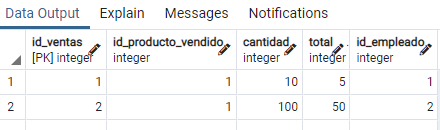

Ahora, si intentamos agregar un producto no registrado en la tabla de ventas nos marcaría un error. Por ejemplo, como en la tabla `productos` sólo tenemos dos productos, ingresemos el id igual a 3 (el cual no existe previamente en la tabla `productos`) en la tabla `ventas`

```
INSERT INTO ventas(id_producto_vendido, cantidad, total, id_empleado) VALUES(3, 100, 50, 2);
```

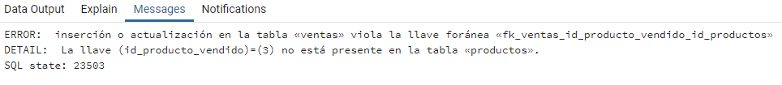

### Ejercicio

1. De acuerdo a la relación de las tablas en tu base de datos (referente al proyecto de la papelería), define las llaves foráneas que sean necesarias. Para ello, si es necesario, tendrás que eliminar y volver a crear tablas para que se acoplen a la definición de las llaves foráneas (como se hizo en clase con la tabla `ventas`).
2. Una vez hecho el punto uno, realiza en cada tabla de tu base de datos al menos tres inserciones.